# Домашнее задание №3. Софья Скобелева

2023-12-07

# Часть 2

## Контекст задачи

*Задача:* рассмотреть связь показателей преступности и числа часов патрулирования полицейских, приходящихся в среднем на 1000 человек.  
В качестве инструментальной переменной для ключевой объясняющей переменной предлагается протестировать показатель instrument. Это дамми-переменная, принимающая значение «1» в случае, если после серии терактов в Лондоне 2005 г. в том или ином районе города власти усилили полицейский патруль, «0» – в противном случае. Усиление произошло благодаря сверхурочной работе, а значит не привело к уменьшению количества полицейских в других районах Лондона.

### Переменные:

*borough* - район Лондона  
*week* - неделя  
*burglary* - число ограблений на 1000 человек  
*theft* - число краж на 1000 человек  
*violence* - число преступлений с применением насилия на 1000 человек *police* - число часов патрулирования полицейских на 1000 человек  
*instrument* - усиление полицейского патруля после террористических актов 2005 г.

```r
data <- read_dta("RAPDC_IV_hw.dta")
```

# Задание 1

Оценим регрессионную модель, в которой откликом выступает число ограблений на 1000 человек, предиктором – число часов патрулирования полицейских на 1000 человек.

```r
model1 <- lm(burglary ~ police,  data = data)
summary(model1)
```

```
##
## Call:
## lm(formula = burglary ~ police, data = data)
##
## Residuals:
##       Min        1Q    Median        3Q       Max
## -0.055291 -0.013467 -0.000293  0.012630  0.076829
##
## Coefficients:
##             Estimate Std. Error t value Pr(>|t|)
## (Intercept) 0.045479   0.000729   62.38   <2e-16 ***
## police      0.152567   0.006567   23.23   <2e-16 ***
## ---
## Signif. codes:  0 '***' 0.001 '**' 0.01 '*' 0.05 '.' 0.1 ' ' 1
##
## Residual standard error: 0.01902 on 3326 degrees of freedom
## Multiple R-squared:  0.1396, Adjusted R-squared:  0.1394
## F-statistic: 539.7 on 1 and 3326 DF,  p-value: < 2.2e-16
```

Значимость для коэффициентов высокая - 0.1%. Взаимосвязь переменных положительная - с ростом числа часов патрулирования полицейских на 1000 человек растет и число ограблений на 1000 человек.Это контринтуитивный вывод.

При равенстве числа часов патрулирования полицейских на 1000 человек нулю число ограблений на 1000 человек в среднем равно примерно 0.045.

При увеличении числа часов патрулирования полицейских на 1000 человек на одну единицу число ограблений на 1000 человек в среднем увеличивается примерно на 0.152 при прочих равных. Однако у данной модели очень низкая долю объясненной вариации зависимой переменной (R2 ≈ 13.96%). Попробуем усовершенствовать модель.Добавим в модель контрольные переменные. Мы работаем с панельными данными, поэтому необходимо добавить фиксированный эфффект либо на время (переменная week) либо на пространство (переменная borough).

```r
model2 <- lm(burglary ~ police + borough + factor(week) + theft + violence,  data = data)
summary(model2)
```

```
##
## Call:
## lm(formula = burglary ~ police + borough + factor(week) + theft +
##     violence, data = data)
##
## Residuals:
##       Min        1Q    Median        3Q       Max
## -0.046616 -0.010018 -0.000507  0.008961  0.052023
##
## Coefficients:
##                   Estimate Std. Error t value Pr(>|t|)
## (Intercept)      3.855e-02  2.817e-03  13.685  < 2e-16 ***
## police          -2.117e-01  1.321e-02 -16.031  < 2e-16 ***
## borough         -1.761e-04  3.465e-05  -5.084 3.91e-07 ***
## factor(week)2   -1.610e-03  3.725e-03  -0.432 0.665597
## factor(week)3   -3.561e-03  3.725e-03  -0.956 0.339213
## factor(week)4   -5.044e-03  3.724e-03  -1.354 0.175689
## factor(week)5   -7.569e-03  3.724e-03  -2.032 0.042204 *
## factor(week)6   -6.049e-03  3.724e-03  -1.625 0.104360
## factor(week)7   -7.758e-03  3.723e-03  -2.083 0.037289 *
## factor(week)8   -4.348e-03  3.724e-03  -1.168 0.243050
## factor(week)9   -8.797e-03  3.725e-03  -2.362 0.018243 *
## factor(week)10  -9.411e-03  3.724e-03  -2.527 0.011542 *
## factor(week)11  -5.857e-03  3.723e-03  -1.573 0.115770
## factor(week)12  -6.639e-03  3.725e-03  -1.782 0.074842 .
## factor(week)13  -1.149e-02  3.724e-03  -3.084 0.002060 **
## factor(week)14  -1.027e-02  3.724e-03  -2.759 0.005830 **
## factor(week)15  -6.699e-03  3.722e-03  -1.800 0.072030 .
## factor(week)16  -4.842e-03  3.724e-03  -1.300 0.193633
## factor(week)17  -9.425e-03  3.726e-03  -2.529 0.011478 *
## factor(week)18  -1.037e-02  3.723e-03  -2.785 0.005379 **
## factor(week)19  -9.514e-03  3.725e-03  -2.554 0.010690 *
## factor(week)20  -9.925e-03  3.727e-03  -2.663 0.007792 **
## factor(week)21  -1.634e-02  3.726e-03  -4.386 1.19e-05 ***
## factor(week)22  -1.212e-02  3.723e-03  -3.256 0.001144 **
## factor(week)23  -1.488e-02  3.726e-03  -3.994 6.64e-05 ***
## factor(week)24  -1.611e-02  3.731e-03  -4.318 1.62e-05 ***
## factor(week)25  -1.394e-02  3.726e-03  -3.740 0.000187 ***
## factor(week)26  -1.301e-02  3.727e-03  -3.492 0.000486 ***
## factor(week)27  -1.199e-02  3.726e-03  -3.217 0.001306 **
```

[output cut: 70 more lines]

```
## factor(week)98   6.199e-04  3.730e-03   0.166 0.868010
## factor(week)99   2.161e-03  3.731e-03   0.579 0.562414
## factor(week)100  3.756e-04  3.732e-03   0.101 0.919847
## factor(week)101  2.579e-03  3.732e-03   0.691 0.489617
## factor(week)102  2.161e-03  3.733e-03   0.579 0.562583
## factor(week)103  4.655e-03  3.728e-03   1.249 0.211900
## factor(week)104 -1.028e-02  3.726e-03  -2.758 0.005856 **
## theft            9.750e-02  4.867e-03  20.033  < 2e-16 ***
## violence         2.647e-01  7.762e-03  34.107  < 2e-16 ***
## ---
## Signif. codes:  0 '***' 0.001 '**' 0.01 '*' 0.05 '.' 0.1 ' ' 1
##
## Residual standard error: 0.01489 on 3220 degrees of freedom
## Multiple R-squared:  0.4897, Adjusted R-squared:  0.4727
## F-statistic: 28.88 on 107 and 3220 DF,  p-value: < 2.2e-16
```

В модели с фиксированным эффектом на время у ключевого предиктора police значимость высокая - на уровне 0.1%. У Interceprt, предикторов borough, theft и violance значимость также высокая - на уровне 0.1%. Также 17 периодов значимы на уровне 0.1%, 16 периодов значимы на уровне 1%, 17 периодов значимы на уровне 5%, 4 периода значимы на уровне 10%. То есть модель объясняет больше половины периодов.

```r
model3 <- lm(burglary ~ police + factor(borough) + week + theft + violence,  data = data)
summary(model3)
```

```
##
## Call:
## lm(formula = burglary ~ police + factor(borough) + week + theft +
##     violence, data = data)
##
## Residuals:
##       Min        1Q    Median        3Q       Max
## -0.039530 -0.007392 -0.000966  0.006659  0.060755
##
## Coefficients:
##                     Estimate Std. Error t value Pr(>|t|)
## (Intercept)        3.734e-02  2.671e-03  13.979  < 2e-16 ***
## police             1.940e-02  1.810e-02   1.072 0.283877
## factor(borough)2   1.517e-02  4.568e-03   3.321 0.000906 ***
## factor(borough)3   2.627e-02  2.055e-03  12.781  < 2e-16 ***
## factor(borough)4   1.057e-02  1.663e-03   6.358 2.32e-10 ***
## factor(borough)5   2.687e-02  1.889e-03  14.222  < 2e-16 ***
## factor(borough)6   1.266e-02  1.869e-03   6.776 1.45e-11 ***
## factor(borough)7   1.638e-02  1.963e-03   8.341  < 2e-16 ***
## factor(borough)8   1.461e-02  1.971e-03   7.413 1.57e-13 ***
## factor(borough)9   1.207e-03  2.042e-03   0.591 0.554429
## factor(borough)10  2.313e-02  1.981e-03  11.673  < 2e-16 ***
## factor(borough)11 -2.508e-03  1.939e-03  -1.294 0.195920
## factor(borough)12  3.035e-02  2.190e-03  13.859  < 2e-16 ***
## factor(borough)13  3.287e-02  2.086e-03  15.756  < 2e-16 ***
## factor(borough)14  2.246e-02  1.849e-03  12.152  < 2e-16 ***
## factor(borough)15  2.583e-02  2.111e-03  12.238  < 2e-16 ***
## factor(borough)16  2.860e-02  2.148e-03  13.315  < 2e-16 ***
## factor(borough)17  1.061e-03  2.077e-03   0.511 0.609680
## factor(borough)18  3.250e-02  2.142e-03  15.172  < 2e-16 ***
## factor(borough)19  1.571e-02  2.035e-03   7.717 1.56e-14 ***
## factor(borough)20 -2.207e-03  2.100e-03  -1.051 0.293286
## factor(borough)21  3.158e-02  2.196e-03  14.382  < 2e-16 ***
## factor(borough)22 -2.226e-03  2.073e-03  -1.074 0.283081
## factor(borough)23  1.335e-02  2.026e-03   6.588 5.17e-11 ***
## factor(borough)24 -2.361e-02  1.998e-03 -11.817  < 2e-16 ***
## factor(borough)25 -8.747e-03  2.018e-03  -4.335 1.50e-05 ***
## factor(borough)26  1.902e-02  1.940e-03   9.804  < 2e-16 ***
## factor(borough)27  4.269e-02  2.122e-03  20.120  < 2e-16 ***
## factor(borough)28  1.505e-02  2.040e-03   7.377 2.04e-13 ***
## factor(borough)29  2.512e-02  1.957e-03  12.835  < 2e-16 ***
## factor(borough)30  2.926e-02  1.822e-03  16.062  < 2e-16 ***
## factor(borough)31  2.334e-02  2.260e-03  10.329  < 2e-16 ***
## factor(borough)32 -1.580e-02  2.096e-03  -7.537 6.16e-14 ***
## week               4.728e-05  7.152e-06   6.611 4.45e-11 ***
## theft              3.285e-02  6.961e-03   4.719 2.46e-06 ***
## violence          -2.849e-02  1.205e-02  -2.365 0.018100 *
## ---
## Signif. codes:  0 '***' 0.001 '**' 0.01 '*' 0.05 '.' 0.1 ' ' 1
##
## Residual standard error: 0.01169 on 3292 degrees of freedom
## Multiple R-squared:  0.6784, Adjusted R-squared:  0.675
## F-statistic: 198.5 on 35 and 3292 DF,  p-value: < 2.2e-16
```

Посмотрим на совместное распределение показателей police и burglary:

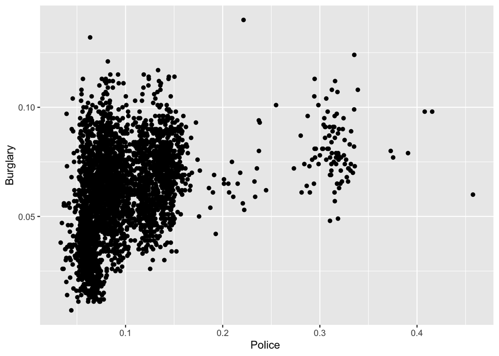

```r
ggplot(data = data, aes(x = police, y = burglary)) +
  geom_point() +
  labs(x = "Police ", y = "Burglary")
```

По графику видно, что связь между переменными нелинейная, наблюдения можно разделить на несколько групп.

На результаты моделей, приведенных выше, нельзя полагаться из-за наличия эндогенности. Потенциальными источниками эндогенности являются  
1)пропущенные значимые переменные,  
2) simultaneity problem - неоднозначность направления причинно-следственной связи предиктора и отклика: непонятно, увеличение числа часов патрулирования влияет на число ограблений или число ограблений влияет на увеличение числа часов патрулирования,  
3) selection bias - в работе рассматриваются только районы Лондона, поэтому могут возникнуть проблемы с обобщением результатов на генеральную совокупность (другие города, города в других странах),  
4) ошибка измерения предиктора police (лучше было бы использовать медианный показатель, так как плотность населения в разных районах различается)

# Задание 2

Инструментальные переменные помогают решить проблему  
эндогенности, поэтому целесообразно обратиться к ним в этой модели. Инструментальные переменный должны соотвествовать следующим требованиям:  
1.Corr(I, T) ≠ 0,  
2.Сorr(I, e) = 0,  
3.Corr(I, u) = 0).

В данной работе предлагается использовать усиление полицейского патруля после террористических актов 2005 г. в качестве инстурментальной переменной.  
Усиление полицейского патруля после терактов действительно коррелирует с ключевым предиктором - с числом часов патрулирования полицейских: усиление полицейского патруля после терактов должно влиять на число часов патрулирования полицейских. Однако усиление полицейского патруля после терактов вероятно влияет и на число преступлений с применением насилия (откывается “черный ход” от ключевого предиктора к отклику).Также к важному ограничению данного инструмента можно отнести то, что скорее всего не во всех районах Лондона были теракты и для них данная инструментальная переменная работать не будет.

# Задание 3

Переоценим модель с использованием инструментальной переменной “усиление полицейского патруля после террористических актов 2005 г.”.  
Оценим модель при помощи двухшагового МНК.На первом шаге оценивается регрессия ключевого предликтора на инструментальную переменную, предсказанные значения ключевого предиктора сохраняются в новую переменную. На втором шаге оценивается регрессия оотклика на предсказанный ключевой предиктор. Таким образом мы оцениваем влияние инструментальной переменной на отклик через ключевой предиктор.

```r
model4_step1 <- lm(police ~ instrument , data)
summary(model4_step1)
```

```
##
## Call:
## lm(formula = police ~ instrument, data = data)
##
## Residuals:
##      Min       1Q   Median       3Q      Max
## -0.09457 -0.03208 -0.01349  0.02359  0.27523
##
## Coefficients:
##              Estimate Std. Error t value Pr(>|t|)
## (Intercept) 0.0977076  0.0008417  116.09   <2e-16 ***
## instrument  0.1441883  0.0088650   16.27   <2e-16 ***
## ---
## Signif. codes:  0 '***' 0.001 '**' 0.01 '*' 0.05 '.' 0.1 ' ' 1
##
## Residual standard error: 0.04834 on 3326 degrees of freedom
## Multiple R-squared:  0.07368,    Adjusted R-squared:  0.0734
## F-statistic: 264.5 on 1 and 3326 DF,  p-value: < 2.2e-16
```

```r
firststage <- model4_step1$fitted.values
model4_step2 <- lm(burglary ~ firststage, data)
summary(model4_step2)
```

```
##
## Call:
## lm(formula = burglary ~ firststage, data = data)
##
## Residuals:
##       Min        1Q    Median        3Q       Max
## -0.053528 -0.014528  0.000472  0.014472  0.079472
##
## Coefficients:
##             Estimate Std. Error t value Pr(>|t|)
## (Intercept) 0.056323   0.002606  21.616   <2e-16 ***
## firststage  0.043035   0.026072   1.651   0.0989 .
## ---
## Signif. codes:  0 '***' 0.001 '**' 0.01 '*' 0.05 '.' 0.1 ' ' 1
##
## Residual standard error: 0.0205 on 3326 degrees of freedom
## Multiple R-squared:  0.0008185,  Adjusted R-squared:  0.0005181
## F-statistic: 2.725 on 1 and 3326 DF,  p-value: 0.09891
```

Сделаем то же самое более коротким способом, а также приведем статистические тесты, чтобы проверить качество выбранного инструмента.

```r
model4 = ivreg(burglary ~ police| instrument, data = data)
summary(model4, diagnostics = TRUE)
```

```
##
## Call:
## ivreg(formula = burglary ~ police | instrument, data = data)
##
## Residuals:
##        Min         1Q     Median         3Q        Max
## -0.0512236 -0.0138033  0.0004175  0.0135487  0.0741467
##
## Coefficients:
##             Estimate Std. Error t value Pr(>|t|)
## (Intercept) 0.056323   0.002517  22.377   <2e-16 ***
## police      0.043035   0.025185   1.709   0.0876 .
##
## Diagnostic tests:
##                   df1  df2 statistic  p-value
## Weak instruments    1 3326    264.55  < 2e-16 ***
## Wu-Hausman          1 3325     22.27 2.47e-06 ***
## Sargan              0   NA        NA       NA
## ---
## Signif. codes:  0 '***' 0.001 '**' 0.01 '*' 0.05 '.' 0.1 ' ' 1
##
## Residual standard error: 0.0198 on 3326 degrees of freedom
## Multiple R-Squared: 0.06766, Adjusted R-squared: 0.06738
## Wald test:  2.92 on 1 and 3326 DF,  p-value: 0.08759
```

Значимость ключевого предиктора police сильно уменьшилась по сравнению с OLS-моделью без инструментальной переменной (с 0.1% до 10%). Различия в результатх могут быть связаны с тем, что при помощи включения инструментальной переменной в модель мы в какой-то степени избавились от эндогенности и изменилась связь переменных.

В соотвествии с тестом на слабость инструмента выбранный инструмент не слабый (p-value ≈ 0 => отвергаем нулевую гипотезу о равенстве корреляции инструмента и ключевого предиктора нулю => инструмент не слабый).  
В соотвествии с Wu-Hausman test более предпочтительной является модель с инструменатльной переменной по сравнению с простно МНК моделью без инструментальной переменной (p-value ≈ 0 => отвергаем нулевую гипотезу о равенстве оценок коэффциентов МНК модели без инструмента и МНК модели с инструментом => предпочтительнее МНК модель с инструментом).  
То есть модель с инструментом предпочтительнее согласно результатам этих двух тестов.

# Задание 4

Проделаем то же для других зависимых переменных: число краж на 1000 человек (theft); число преступлений с применением насилия на 1000 человек (violence).

Оценим регрессионную модель, в которой откликом выступает число краж на 1000 человек, предиктором – число часов патрулирования полицейских на 1000 человек.

```r
model_theft = lm(theft ~ police, data)
summary(model_theft)
```

```
##
## Call:
## lm(formula = theft ~ police, data = data)
##
## Residuals:
##      Min       1Q   Median       3Q      Max
## -0.32354 -0.03527 -0.00653  0.03295  0.25701
##
## Coefficients:
##              Estimate Std. Error t value Pr(>|t|)
## (Intercept) -0.003227   0.002217  -1.455    0.146
## police       2.241104   0.019975 112.194   <2e-16 ***
## ---
## Signif. codes:  0 '***' 0.001 '**' 0.01 '*' 0.05 '.' 0.1 ' ' 1
##
## Residual standard error: 0.05786 on 3326 degrees of freedom
## Multiple R-squared:  0.791,  Adjusted R-squared:  0.7909
## F-statistic: 1.259e+04 on 1 and 3326 DF,  p-value: < 2.2e-16
```

Intercept в данной модели незначим, коэффициент при ключевом предикторе police значим на уровне значимости 0.1%. Взаимосвязь переменных положительная - с ростом числа часов патрулирования полицейских на 1000 человек растет и число краж на 1000 человек.Это контринтуитивный вывод. Включим инструментальную переменную:

```r
model_theft2 = ivreg(theft ~ police| instrument, data = data)
summary(model_theft2, diagnostics = TRUE)
```

```
##
## Call:
## ivreg(formula = theft ~ police | instrument, data = data)
##
## Residuals:
##      Min       1Q   Median       3Q      Max
## -0.15892 -0.05166 -0.01128  0.02678  0.48137
##
## Coefficients:
##             Estimate Std. Error t value Pr(>|t|)
## (Intercept)  0.11465    0.01058  10.840   <2e-16 ***
## police       1.05053    0.10583   9.927   <2e-16 ***
##
## Diagnostic tests:
##                   df1  df2 statistic p-value
## Weak instruments    1 3326     264.5  <2e-16 ***
## Wu-Hausman          1 3325     308.7  <2e-16 ***
## Sargan              0   NA        NA      NA
## ---
## Signif. codes:  0 '***' 0.001 '**' 0.01 '*' 0.05 '.' 0.1 ' ' 1
##
## Residual standard error: 0.0832 on 3326 degrees of freedom
## Multiple R-Squared: 0.5678,  Adjusted R-squared: 0.5676
## Wald test: 98.54 on 1 and 3326 DF,  p-value: < 2.2e-16
```

Intercept и коэффициент при ключевом предикторе police значимы на уровне значимости 0.1%. По сравнению с OLS-моделью без инстурмента ключевой предиктор police не потерял значимость. Можно говорить, что при увеличении числа часов патрулирования полицейских на 1000 человек на 1 час в среднем число краж на 1000 человек растет на 1.05053 при прочих равных условиях. Видимо, такой вывод получается из-за проблемы неоднозначного направления причинно-следственной связи, так как увеличении числа часов патрулирования вероятно происходит в тех районах, где совершается много преступлений, и в том числе краж.

В соотвествии с тестом на слабость инструмента выбранный инструмент не слабый (p-value ≈ 0 => отвергаем нулевую гипотезу о равенстве корреляции инструмента и ключевого предиктора нулю => инструмент не слабый).  
В соотвествии с Wu-Hausman test более предпочтительной является модель с инструменатльной переменной по сравнению с простно МНК моделью без инструментальной переменной (p-value ≈ 0 => отвергаем нулевую гипотезу о равенстве оценок коэффциентов МНК модели без инструмента и МНК модели с инструментом => предпочтительнее МНК модель с инструментом).  
То есть модель с инструментом предпочтительнее согласно результатам этих двух тестов.

```r
model_violance = lm(violence ~ police, data)
summary(model_violance)
```

```
##
## Call:
## lm(formula = violence ~ police, data = data)
##
## Residuals:
##       Min        1Q    Median        3Q       Max
## -0.126203 -0.026876 -0.000213  0.024604  0.123062
##
## Coefficients:
##             Estimate Std. Error t value Pr(>|t|)
## (Intercept) 0.071188   0.001364   52.19   <2e-16 ***
## police      0.472075   0.012288   38.42   <2e-16 ***
## ---
## Signif. codes:  0 '***' 0.001 '**' 0.01 '*' 0.05 '.' 0.1 ' ' 1
##
## Residual standard error: 0.03559 on 3326 degrees of freedom
## Multiple R-squared:  0.3073, Adjusted R-squared:  0.3071
## F-statistic:  1476 on 1 and 3326 DF,  p-value: < 2.2e-16
```

```r
model_violance2 = ivreg(violence ~ police| instrument, data = data)
summary(model_violance2, diagnostics = TRUE)
```

```
##
## Call:
## ivreg(formula = violence ~ police | instrument, data = data)
##
## Residuals:
##       Min        1Q    Median        3Q       Max
## -0.090493 -0.032921  0.000849  0.029377  0.141494
##
## Coefficients:
##             Estimate Std. Error t value Pr(>|t|)
## (Intercept) 0.107067   0.005082  21.069   <2e-16 ***
## police      0.109687   0.050847   2.157   0.0311 *
##
## Diagnostic tests:
##                   df1  df2 statistic p-value
## Weak instruments    1 3326    264.55  <2e-16 ***
## Wu-Hausman          1 3325     70.62  <2e-16 ***
## Sargan              0   NA        NA      NA
## ---
## Signif. codes:  0 '***' 0.001 '**' 0.01 '*' 0.05 '.' 0.1 ' ' 1
##
## Residual standard error: 0.03998 on 3326 degrees of freedom
## Multiple R-Squared: 0.1262,  Adjusted R-squared: 0.126
## Wald test: 4.653 on 1 and 3326 DF,  p-value: 0.03106
```

Intercept значим на уровне значимости 0.1%. Коэффициент при ключевом предикторе police потерял значимость по сравнению с OLS-моделью без инстурмента: теперь он значим на уровне значимости 5%: а не 0.1% Можно говорить, что при увеличении числа часов патрулирования полицейских на 1000 человек на 1 час в среднем число преступлений с применением насилия на 1000 человек растет на 0.109687 при прочих равных условиях. Здесь так же такой вывод получается из-за проблемы неоднозначного направления причинно-следственной связи, так как увеличении числа часов патрулирования вероятно происходит в тех районах, где совершается много преступлений, и в том числе число преступлений с применением насилия.

В соотвествии с тестом на слабость инструмента выбранный инструмент не слабый (p-value ≈ 0 => отвергаем нулевую гипотезу о равенстве корреляции инструмента и ключевого предиктора нулю => инструмент не слабый).  
В соотвествии с Wu-Hausman test более предпочтительной является модель с инструменатльной переменной по сравнению с простно МНК моделью без инструментальной переменной (p-value ≈ 0 => отвергаем нулевую гипотезу о равенстве оценок коэффциентов МНК модели без инструмента и МНК модели с инструментом => предпочтительнее МНК модель с инструментом).  
То есть модель с инструментом предпочтительнее согласно результатам этих двух тестов.